# Población con estructura de clases

# La gran *evisón*

> Los visones que se escaparon en el episodio anterior alcanzan la madurez sexual a los 10 o 12 meses y, por ello, solo una de cada diez hembras tiene durante el primer año un par de crías. En el segundo año tienen una media de 6 crías/hembra y, debido a las vicisitudes del ambiente, su esperanza de vida no va más allá de 2 años. ¿Cómo se deducen $r$ y $\lambda$ a partir de estos datos?

### Los dichosos visones

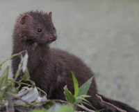

Consideremos dos clases de edad en la población de visones: $J$ juveniles hasta 1 año y adultos $A$ a partir de ahí.

> ¿Cuántos visones nacen cada año?

Si llamamos $J_t$ y $A_t$ al número de juveniles y adultos del año $t$, respectivamente, y suponiendo que la mitad sean hembras, el número de juveniles que habrá el año siguiente será

$$J_{t + 1} = 0.1 J_t + 3 A_t$$

es decir, promediando por individuo macho o hembra, 0.1 crías por cada juvenil más 3 crías por cada adulto.

> ¿Cuántos juveniles llegan a adultos cada año?

Esto es un poco más difícil de saber con los datos iniciales. Podríamos decir *«si todos los visones mueren con 2 años, la mitad habrá muerto con 1 año»* pero ya sabemos que la ecuación exponencial esconde sorpresas. Esto lo analizaremos más tarde, por ahora, supongamos que es así y tendremos

$$A_{t + 1} = 0.5 J_t$$

> Sistema de ecuaciones y grafo

Las dos ecuaciones anteriores forman el siguiente sistema:

$$\begin{align}
J_{t + 1} &= 0.1 J_t + 3 A_t \\
A_{t + 1} &= 0.5 J_t
\end{align}$$

que se puede expresar también como *grafo*:

[figure not shown]

**Grafo de las clases de edad del visón.** Los círculos representan las clases y las flechas entre ellos el factor por el que se multiplica la abundancia entre años consecutivos.

> Dinámica temporal

Supongamos que inicialmente se escaparon 100 juveniles, esto es:

$$\begin{align}
J_{0} &= 100 \\
A_{0} &= 0
\end{align}$$

Cuando pase un año, tendríamos

$$\begin{align}
J_{1} &= 0.1 J_0 + 3 A_0 = 10 + 0 = 10 \\
A_{1} &= 0.5 J_0 = 50
\end{align}$$

Y al siguiente

$$\begin{align}
J_{2} &= 151 \\
A_{2} &= 5
\end{align}$$

Y así, así, estos serían los primeros 12 años:

Primeros doce años de la población. La abundancia se ha redondeado sin decimales.

| Año (t) | Juveniles | Adultos | Total |
| --- | --- | --- | --- |
| 0 | 100 | 0 | 100 |
| 1 | 10 | 50 | 60 |
| 2 | 151 | 5 | 156 |
| 3 | 30 | 76 | 106 |
| 4 | 230 | 15 | 245 |
| 5 | 68 | 115 | 183 |
| 6 | 351 | 34 | 385 |
| 7 | 137 | 176 | 313 |
| 8 | 540 | 69 | 609 |
| 9 | 260 | 270 | 530 |
| 10 | 837 | 130 | 966 |
| 11 | 474 | 418 | 892 |
| 12 | 1302 | 237 | 1539 |

En forma gráfica,

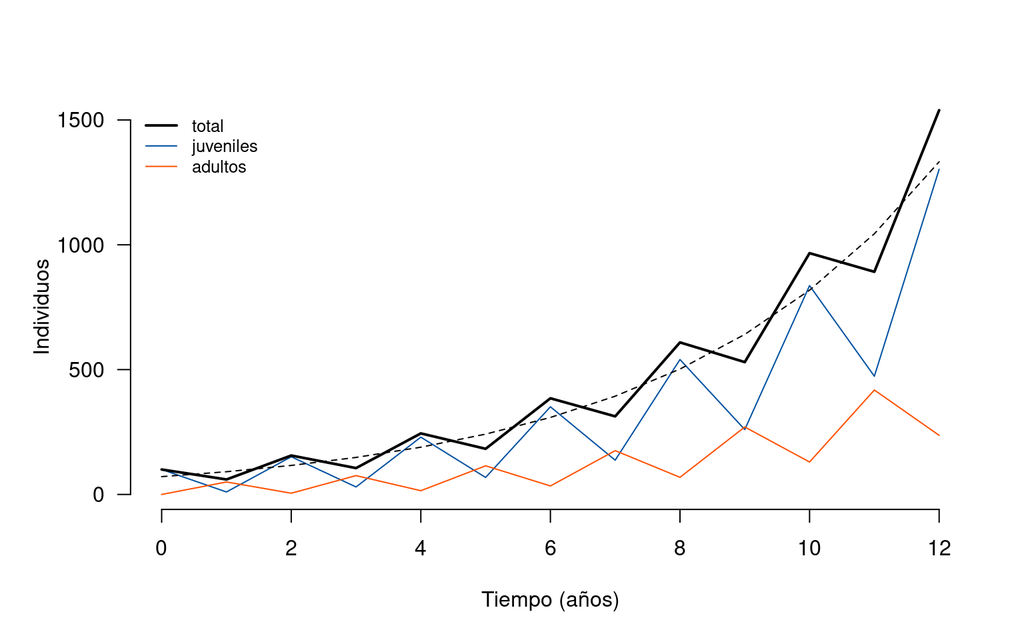

**Dinámica prevista en la población.** Aunque hay muchos altibajos, se aprecia claramente el aumento geométrico del número total de individuos. La forma en *dientes de sierra* será objeto de análisis más adelante. La línea de puntos representa el ajuste exponencial a la población total.

> Parámetros $r$ y $\lambda$

El ajuste exponencial de la abundancia total estima una tasa intrínseca de crecimiento $r = 0.24$ años⁻¹ que equivale a un $\lambda = 1.28$ anual. Sin embargo, cuando intentamos deducir $\lambda$ directamente de la tabla nos llevamos una sorpresa:

Valores de $\lambda$ deducidos como cocientes entre abundancias consecutivas.

| Año (t) | Total | $\lambda$ |
| --- | --- | --- |
| 0 | 100 |  |
| 1 | 60 | 0.60 |
| 2 | 156 | 2.60 |
| 3 | 106 | 0.68 |
| 4 | 245 | 2.32 |
| 5 | 183 | 0.75 |
| 6 | 385 | 2.11 |
| 7 | 313 | 0.81 |
| 8 | 609 | 1.95 |
| 9 | 530 | 0.87 |
| 10 | 966 | 1.82 |
| 11 | 892 | 0.92 |
| 12 | 1539 | 1.73 |

A causa de la dinámica oscilante, el cociente entre abundancias consecutivas también oscila. Aunque, si nos fijamos bien, parece que las oscilaciones se van reduciendo. Veamos una predicción más larga.

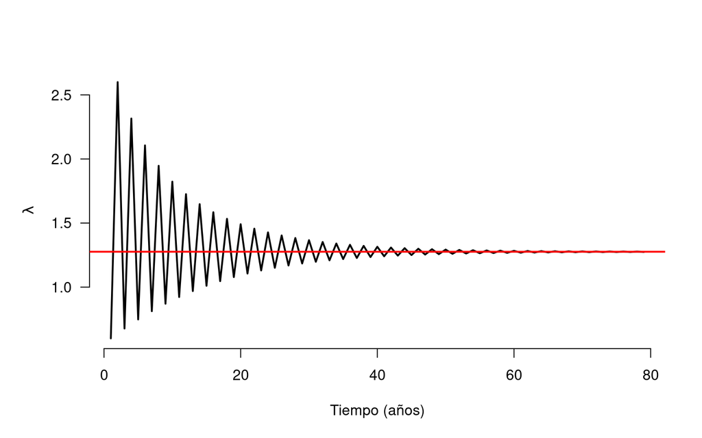

**Valores de $\lambda$ calculados entre abundancias consecutivas.** La línea negra muestra las oscilaciones del cociente. La línea roja es el valor de $\lambda$ calculado a partir del ajuste exponencial de $r$.

Parece que, con el tiempo, las oscilaciones disminuyen y el factor de aumento entre cada año tiende a un valor constante que coincide con el estimado por el ajuste exponencial.

Además, si $\lambda$ se hace constante entonces también deben cesar las oscilaciones en la abundancia total y, consecuentemente, en las de cada clase. Comprobémoslo:

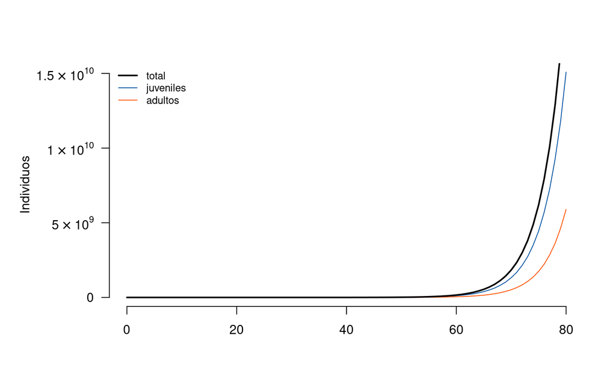

**Cuando pasa suficiente tiempo, cesan las oscilaciones.** Tanto la abundancia total como las de cada clase dejan de oscilar y siguen una tendencia estrictamente exponencial.

# Misma población, distintos individuos

En el episodio anterior hemos tratado con poblaciones cuyos individuos eran estrictamente idénticos entres sí. Para ser más realistas, habría que tener en cuenta a los organismos que pasan por distintas fases a lo largo de su vida (como los visones del ejemplo) porque su contribución a la siguiente generación también cambia. Aunque, en promedio, sigue siendo válida la teoría anterior, merece la pena estudiar con más detalle la dinámica de una población con clases de edad y desentrañar la extraña magia que suaviza todo a largo plazo.

## Una de nombres

Aunque el tiempo, la edad, sea una variable continua, cuando te preguntan cuántos años tienes respondes con un entero: el número de años completos que han pasado desde tu nacimiento. Es un criterio tan asentado en el uso cotidiano que merece la pena mantenerlo aquí también.

[figure not shown]

**Nomenclatura de edades y abundancias.** La edad $x$ es una variable continua pero se necesitan clases discretas, así que se agrupan individuos por edades cumplidas. La abundancia de cada clase se representa con la letra $n_i$ donde $x = 0, 1, 2, \cdots, m$ son las edades cumplidas según el criterio tradicional.

La última clase no tiene un final definido: está formada por individuos que han cumplido $m$ años pero no llegarán a cumplir $m+1$. Mantendremos esta cruel convención durante los primeros pasos, pero después podremos ser menos estrictos.

## Grafo del caso general

Antes de liarnos con las matemáticas, veamos el grafo correspondiente a una población con $m + 1$ clases:

[figure not shown]

**Grafo de una población con $m + 1$ clases.** La abundancia de cada clase se representa con la letra $n_x$. Del mismo modo, $f_x$ es la fecundidad o número de crías per cápita de la clase $x$. Finalmente, $s_x$ es la supervivencia desde la clase $x$ a la siguiente $x+1$.

En el grafo anterior se asume que:

- Todas las clases puede aportar nuevos individuos a la primera clase.
- Los individuos de una clase, o sobreviven hasta la siguiente, o bien mueren.
- No pueden saltarse clases o, en términos equivalentes, todas las clases tienen la misma duración.
- Los individuos de la última clase mueren una vez transcurrido este periodo de duración.

## Ecuaciones del caso general

Como hay $m + 1$ clases tendremos otras tantas ecuaciones. Aunque muy sencillas, hay que tener un poco de cuidado con la nomenclatura: llamaremos $n_{x, t}$ a la abundancia de la clase $x$ en el tiempo $t$, de modo que $n_{x, t+1}$ será $n_x$ en el siguiente tiempo.

Siguiendo el ejemplo, los nuevos nacimientos que entran directamente en la primera clase son

$$n_{0,t+1} = \sum_{x=0}^{m} f_x n_{x, t}$$

es decir, la suma de los productos de fecundidad per cápita de cada clase por el número de individuos que se han reproducido en el tiempo correspondiente.

Y las demás abundancias en $t+1$ procederán del número de individuos de la clase inferior, multiplicados por su superviviencia:

$$n_{x,t+1} = s_{x-1} n_{x-1, t} \quad \text{para } 1 \leq x \leq m$$

# Matriz de Leslie

Es fácil equivocarse con tanto subíndice. Afortunadamente, la forma lineal de las ecuaciones permite convertir el conjunto en el producto de una matriz por un vector. Observa:

$$\begin{pmatrix}
n_0 \\
n_1 \\
\vdots \\
n_{m-1} \\
n_m
\end{pmatrix}_{t+1}
=
\begin{pmatrix}
f_0 & f_1 & \cdots & f_{m-1} & f_m \\
s_0 & 0 & \cdots & 0 & 0 \\
0 & s_1 & \cdots & 0 & 0 \\
\vdots & \vdots & \ddots & \vdots & \vdots \\
0 & 0 & \cdots & s_{m-1} & 0
\end{pmatrix}
\times
\begin{pmatrix}
n_0 \\
n_1 \\
\vdots \\
n_{m-1} \\
n_m
\end{pmatrix}_{t}$$

mamotreto que podemos resumir como

$$\mathbf{N}_{t+1} = \mathbf{L} \times \mathbf{N}_t$$

El vector $\mathbf{N}$ está formado por las abundancias de las $m + 1$ clases y la matriz $\mathbf{L}$, cuadrada de tamaño $(m + 1) \times (m + 1)$, la llamamos así en honor de [P. H. Leslie](https://www.jstor.org/stable/2332297), al que se le ocurrió en 1945.

### Matriz de los visones

El sistema matricial que corresponde con el ejemplo es

$$\begin{pmatrix}
J \\
A
\end{pmatrix}_{t+1}
=
\begin{pmatrix}
0.1 & 3 \\
0.5 & 0
\end{pmatrix}
\times
\begin{pmatrix}
J \\
A
\end{pmatrix}_{t}$$

Veamos los primeros años,

$$\begin{align}
\mathbf{N}_0 &=
\begin{pmatrix}
100 \\
0
\end{pmatrix} \\[1em]
\mathbf{N}_1 &=
\begin{pmatrix}
0.1 & 3 \\
0.5 & 0
\end{pmatrix}
\times
\begin{pmatrix}
100 \\
0
\end{pmatrix}
=
\begin{pmatrix}
0.1 \times 100 + 3 \times 0 \\
0.5 \times 100 + 0 \times 0
\end{pmatrix}
=
\begin{pmatrix}
10 \\
50
\end{pmatrix} \\[1em]
\mathbf{N}_2 &=
\begin{pmatrix}
0.1 & 3 \\
0.5 & 0
\end{pmatrix}
\times
\begin{pmatrix}
10 \\
50
\end{pmatrix}
=
\begin{pmatrix}
151 \\
5
\end{pmatrix} \\[1em]
\cdots
\end{align}$$

Podemos imaginar el vector representado en un plano cartesiano cuyas coordenadas sean la abundancia de juveniles y adultos, por ejemplo $J$ como eje de abscisas y $A$ como eje de ordenadas. ¿Qué aspecto tendría la dinámica temporal del vector?

[video not shown]

**Dinámica del vector que representa a la población.** Conforme pasa el tiempo, la dirección del vector va alternando alrededor de una dirección mágica hasta que, finalmente, se queda apuntando ahí. Al mismo tiempo, tanto la proporción adultos/juveniles como $\lambda$ van aproximándose progresivamente a unos valores concretos. Esto ocurre siempre, independientemente de las abundancias iniciales. Es otra perspectiva de lo que ocurría en el cuadro anterior.

**¿Qué clase de magia es esta?**

## Vectores y valores propios

Para entender lo que ocurre hay que repasar un poco de álgebra matricial. Podemos interpretar una matriz como una máquina en la que entra un vector y sale transformado en otro. De hecho, es lo que significa la última ecuación escrita arriba. Dependiendo de cómo sea el vector de entrada, así será el salida aunque, curiosamente, hay vectores que salen tal como entran. Como lo oyes.

Estos vectores que atraviesan impasibles la matriz se llaman *vectores propios* y cada matriz tiene los suyos. En realidad, cuando un vector propio pasa por la matriz sale un poco más largo o un poco más corto, pero apuntando en la misma dirección, que es lo importante para los matemáticos. La proporción en la que cambia un vector propio al multiplicarse por su matriz se llama *valor propio*. Una matriz cuadrada tiene tantos valores propios como indique su rango y, normalmente, en nuestro caso siempre coincide con el número de clases.

El primer valor propio de la matriz de Leslie y su vector propio asociado están relacionados con la tasa exponencial de crecimiento y con las proporciones entre las abundancias de distintas clases.

#### Vectores y valores propios para los visones

Como hemos visto antes, la matriz que representa la dinámica de la población de visones es

$$\mathbf{L} = \begin{pmatrix}
0.1 & 3 \\
0.5 & 0
\end{pmatrix}$$

Vamos a encontrar sus vectores y valores propios. Así que resolvemos la ecuación

$$\mathbf{L} \times \mathbf{U} = \lambda \mathbf{U}$$

es decir,

$$\mathbf{L} \times \mathbf{U} - \lambda \mathbf{U} = 0$$

para sacar factor común $\mathbf{U}$ tenemos que dejar a $\lambda$ multiplicada por $\mathbf{I}$, la matriz identidad (todo ceros, salvo la diagonal principal de unos).

$$\left( \mathbf{L} - \lambda \mathbf{I} \right) \times \mathbf{U} = 0$$

Como $\mathbf{U}$ tiene que ser distinto de 0 para que el asunto tenga interés, tiene que ser la matriz $\left( \mathbf{L} - \lambda \mathbf{I} \right)$ la que anule el producto. Las matrices que hacen esto se llaman *singulares* y se caracterizan por tener un rango inferior a su tamaño, no tener inversa y un determinante nulo (una *joyita matemática* vamos). Así que tenemos que resolver

$$\lvert {\mathbf{L} - \lambda \mathbf{I}} \lvert = 0$$

que, en forma desarrollada para los visones es

$$\begin{vmatrix}
0.1 - \lambda & 3 \\
0.5 & 0 - \lambda
\end{vmatrix}
=
0$$

es un determinante fácil: producto de la diagonal principal menos el producto de la otra diagonal:

$$(0.1 - \lambda)(0 - \lambda) - 3·0.5 = 0$$

es decir, un polinomio de segundo grado:

$$\lambda^2 - 0.1 \lambda - 1.5 = 0$$

que tiene dos soluciones (nuestros dos valores propios) ordenados de mayor a menor:

$$\begin{align}
\lambda_1 &= \phantom{-}1.28 \\
\lambda_2 &= -1.18
\end{align}$$

¡El primero coincide con valor al que tendía el cociente entre abundancias consecutivas!

Veamos su vector propio asociado, para ello recuperamos cualquier definición de valor y vector propio, por ejemplo $\left( \mathbf{L} - \lambda \mathbf{I} \right) \times \mathbf{U} = 0$, que ahora desarrollamos sustituyendo

$$\lambda_1 = 1.28
;\qquad
\mathbf{U}_1 = \begin{pmatrix}
u_{11} \\
u_{12}
\end{pmatrix}$$

y tenemos

$$\begin{pmatrix}
0.1 - 1.28 & 3 \\
0.5 & 0-1.28
\end{pmatrix}
\times
\begin{pmatrix}
u_{11} \\
u_{12}
\end{pmatrix}
=
\begin{pmatrix}
0 \\
0
\end{pmatrix}$$

es decir, un sistema de dos ecuaciones con dos incógnitas:

$$\begin{align}
-1.18\;u_{11} + \phantom{.33}3\;u_{12} &= 0 \\[0.5em]
0.5\;u_{11} - 1.28\;u_{12} &= 0
\end{align}$$

que, como ya esperábamos, es un sistema de ecuaciones indeterminado porque $\mathbf{L}-\lambda\mathbf{I}$ es singular (las dos ecuaciones son equivalentes). En otras palabras, exiten infinitas combinaciones de $u_{11}$ y $u_{12}$ que las cumplen, es decir, infinitos vectores semejantes a $\mathbf{U}_1$.

Para obtener uno de ellos se da un valor cualquiera a una componente y se obtiene la otra de cualquiera de las dos ecuaciones. Por ejemplo, si

$$u_{11} = 1$$

de la segunda ecuación obtenemos

$$u_{12} = \frac{0.5}{1.28} = 0.39$$

¡Justo la proporción $A/J$ que aparece al final de la simulación!

De la misma forma se obtiene un representante de $\mathbf{U}_2$ y ya tenemos los valores y vectores propios para la población de visones:

$$\lambda_1 = 1.28
;\qquad
\mathbf{U}_1 = \begin{pmatrix}
1 \\
0.39
\end{pmatrix} \\[2em]
\lambda_2 = -1.18
;\qquad
\mathbf{U}_2 = \begin{pmatrix}
1 \\
-0.43
\end{pmatrix}$$

> Significado de $\lambda$ y $\mathbf{U}$

El primer valor propio $\lambda_1 = 1.28$ y su vector propio asociado $\mathbf{U}_1 = (1, 0.39)$ son, respectivamente, la tasa finita de crecimiento y las proporciones entre clases de la población cuando se estabilizan en el tiempo.

El significado de $\lambda_2$ y $\mathbf{U}_2$ es, sin embargo, más difícil de interpretar. Aunque cumplen los requisitos matemáticos, ecológicamente no tiene sentido el valor negativo de la tasa finita de crecimiento ni, mucho menos, la abundancia de una clase.

Antes hemos visto la matriz como una máquina que transforma vectores, en este caso, vectores con dos dimensiones, dos coordenadas. La matriz cambia ambas coordenadas simultáneamente, de forma que las nuevas coordenadas dependen de las antiguas. Con la matriz en su forma original, el nuevo valor de una de las coordenadas depende de las dos anteriores (por ejemplo, los nuevos juveniles dependen de los juveniles y adultos previos). Esto ocurre porque el sistema de coordenadas donde se define la matriz original no es linealmente independiente.

Los vectores propios de una matriz forman entre ellos un sistema de coordenadas linealmente independiente. Mira la figura siguiente.

[interactive chart not shown]

**Vectores propios y abundancias de la población de visones.** Los vectores propios de $\mathbf{L}$ aparecen en gris, entre ellos forman un sistema de coordenadas independientes para el vector que representa las abundancias de juveniles y adultos. Aquí, $\mathbf{N}_t$ tiene coordenadas $(a, b)$, la primera ($a$) sobre el primer vector propio $\mathbf{U}_1$, el correspondiente a $\lambda_1$ (el valor propio más grande) y $b$ sobre $\mathbf{U}_2$, el segundo vector propio. Con este nuevo sistema de referencia, el valor futuro $\mathbf{N}_{t+1}$ tiene unas coordenadas independientes, directamente proporcionales a $(a, b)$; solo hay que multiplicarlas por $\lambda_1$ y $\lambda_2$, respectivamente. Puedes mover el punto naranja para comprobar cómo responde el azul.

> ¿Por qué se tiende siempre al equilibrio?

Hemos comprobado *experimentalmente* que el vector $\mathbf{N}$, al ir pasando una y otra vez por la matriz $\mathbf{L}$ acaba pareciéndose cada vez más al primer vector propio $\mathbf{U}_1$. La explicación intuitiva está en la figura: el vector futuro (azul) siempre es más largo que el presente (naranja) pero se alarga más en la dirección que marca el primer vector propio. Además, como $\lambda_2$ es negativo, el vector de estado va cambiando alternativamente a cada lado de $\mathbf{U}_1$ (puedes comprobarlo en la figura interactiva) a la vez que el ángulo que forma con él va cerrándose. Esta dinámica se repite indefinidamente hasta que el vector azul acaba superpuesto con $\mathbf{U}_1$.

Por eso el primer valor propio siempre está asociado al vector que representa la estructura de clases estable. La rapidez con la que se llega al equilibrio está relacionada con el segundo valor propio $\lambda_2$: cuanto menor sea su valor absoluto en relación con $\lambda_1$ más rápidamente será la tendencia a la estabilidad.

## Crecimiento exponencial y distribución estable de edades

> El primer valor propio de la matriz de Leslie es la tasa finita de crecimiento $\lambda$ y su vector propio asociado representa la distribución estable de clases.

A partir de la matriz de Leslie de una población, sin necesidad de saber nada más, se puede deducir el futuro de la misma. La tasa de crecimiento exponencial y las proporciones entre clases de individuos está a tiro de álgebra, como hemos visto.

# Tabla de vida

¿Y al revés? ¿Se pueden deducir los parámetros demográficos que constituyen la matriz a partir de la observación directa de la dinámica poblacional?

### Los topillos salvajes de Leslie y Ranson

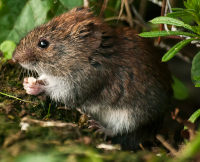

Uno de los trabajos que inspiró a Leslie lo hizo con su colega R. M. Ranson, dirigidos ambos por Charles Elton. En [este artículo](https://www.jstor.org/stable/1425?seq=1) se vislumbra el rumbo matricial que tomaría el asunto unos años más tarde.

El verdadero protagonista es *Microtus agrestis*, al que criaron en cautividad para aprender sobre su prolífica vida.

> Seguimiento de la población

Leslie y Ranson iniciaron la población con 85 machos y 34 hembras, pero se dieron cuenta de que era mucho más sencillo hacer los cálculos solo con las hembras. La tabla representa la dinámica simplificada que habría seguido la población de acuerdo con los resultados que obtuvieron.

Evolución de la población durante los primeros 20 meses. Solo se cuentan las hembras. Cada clase de edad dura 4 meses.

| Clase | Edad (meses) | may | sep | ene | may | sep | ene |
| --- | --- | --- | --- | --- | --- | --- | --- |
| 0 | 0 | 34 | 24 | 152 | 264 | 838 | 1899 |
| 1 | 4 | 0 | 25 | 18 | 111 | 193 | 612 |
| 2 | 8 | 0 | 0 | 15 | 11 | 65 | 114 |
| 3 | 12 | 0 | 0 | 0 | 6 | 5 | 27 |
| 4 | 16 | 0 | 0 | 0 | 0 | 2 | 1 |

> Supervivencia entre clases $s_x$

De las 34 hembras iniciales solo quedaban 25 a los cuatro meses, esto significa un 74 % de supervivencia entre la clase 0 y la clase 1. Del mismo modo se calculan las demás supervivencias. Observa que la tabla se ha hecho de manera que el periodo de muestreo coincide con la duración de cada clase. Si no fuese así habría que elegir fechas separadas por cuatro meses, o usar clases de edad más breves.

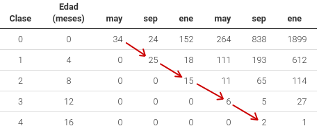

**Supervivencia entre clases.** Las flechas rojas indican la supervivencia desde la clase $x$ a la $x+1$.

> Curva de supervivencia $l_x$

La supervivencia entre clases es útil para construir la matriz de Leslie, pero la supervivencia hasta cierta edad puede ser más útil en general. Veamos en forma gráfica el porcentaje de individuos que sobrevive hasta cierta edad:

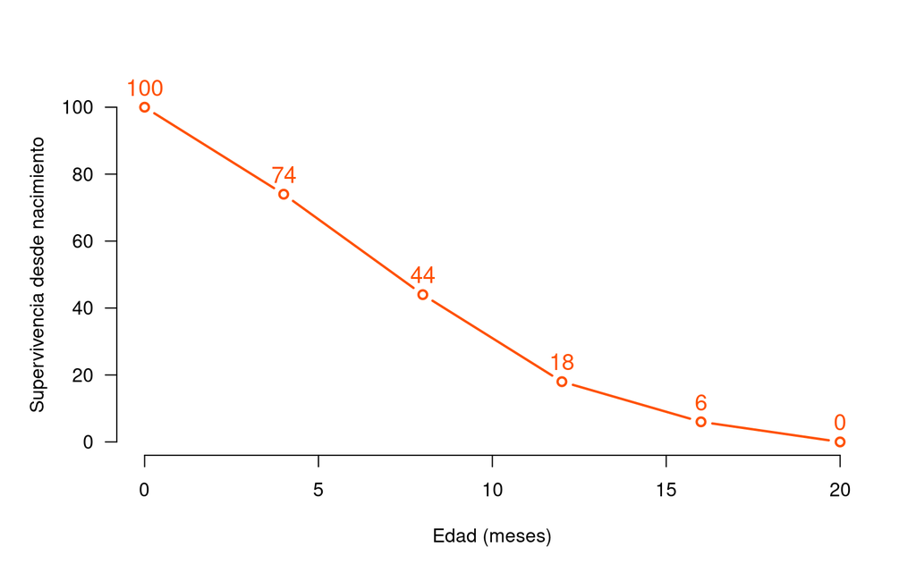

**Supervivencia desde el nacimiento.** Expresa el porcentaje de individuos que llegan hasta cierta edad. Cuando se expresa como fracción se suele llamar $l_x$ y se puede interpretar también como la probabilidad de llegar a esa edad.

> Fecundidad de cada clase $f_x$

El número de crías por clase también se puede deducir de la tabla, aunque no es tan inmediato, salvo la primera: las 24 hembras de septiembre son hijas de las 34 que había en mayo, lo cual da una tasa de fecundidad de 0.7 crías/hembra.

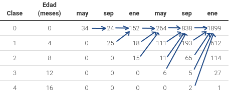

**Fecundidad de cada clase.** Conforme pasa el tiempo, las nuevas crías proceden de madres de más clases, lo que complica un poco el cálculo de la fecundidad por hembra de cada edad.

Tampoco es para tanto, si seguimos un orden. En enero hay 152 crías que son hijas de las 24 hembras de las clases 0 y 1 del septiembre anterior. Suponiendo que la fecundidad de las hembras 0 siga siendo 0.7, éstas habrán aportado 0.7 × 24 = 17, así que las 135 restantes son hijas de las hembras de la clase 1, cuya tasa de fecundidad será, por tanto, 135/25 = 5.4 crías/hembra.

Para la fecundidad de la clase 2 hay que descontar las anteriores. Se puede hacer como en el párrafo anterior, o ser un poco más ordenado:

$$264 = 0.7 \times 152 + 5.4 \times 18 + f_2 \times 15$$

de donde se deduce $f_2 = 4.0$ crías/hembra.

Del mismo modo recurrente salen $f_3 = 1.6$ y $f_4 = 1.1$ crías/hembra, respectivamente.

> Tabla de vida

Una vez deducidos los parámetros poblacionales, se pueden resumir en una tabla cuya utilidad veremos dentro de un rato.

Tabla de vida para *Microtus agrestis*.

| Clase | Edad (meses) | $s_x$ | $l_x$ | $f_x$ |
| --- | --- | --- | --- | --- |
| 0 | 0 | 0.74 | 1.00 | 0.7 |
| 1 | 4 | 0.60 | 0.74 | 5.4 |
| 2 | 8 | 0.40 | 0.44 | 4.0 |
| 3 | 12 | 0.33 | 0.18 | 1.6 |
| 4 | 16 | 0.00 | 0.06 | 1.1 |

## ¿Cuánto aporta un individuo a la población?

La tabla de vida proporciona la base para responder a muchas preguntas con sentido biológico, como la contribución que hace un individuo al crecimiento de la población. La respuesta más directa a esta se consigue sumando todos los descendientes que tiene el individuo a lo largo de su vida.

Un individuo que llega hasta la última clase habrá aportado $\sum f_x$ descendientes directos a la población. Como no todos llegan a la última clase, ese valor debe ser modificado por la probabilidad de llegar a cada edad, de forma que la contribución directa de un individuo es

$$R_0 = \sum_{x=0}^m l_x f_x$$

número que se suele llamar *tasa reproductiva neta*. Su interpretación intuitiva es sencilla: si R<sub>0</sub> = 1 esto significa que cada individuo –en promedio– dejará un descendiente directo, de forma que la población mantendrá una abundancia constante durante sucesivas generaciones. Si es mayor que 1 o menor, respectivamente, la población crecerá o disminuirá. En el caso de los topillos R<sub>0</sub> = 6.8, es decir, una topilla tendrá 6.8 hijas a lo largo de su vida. Si la proporción de sexos fuese 1:1 también se podría decir lo mismo de los machos.

En realidad, el aporte de un individuo a la población puede ser mucho mayor si se tienen en cuenta los nietos, bisnietos, tataranietos… que pudieran nacer durante la vida del individuo.

> Relación entre $\lambda$ y $R_0$

La tasa finita de crecimiento $\lambda$ es el factor en que aumenta la población cuando transcurre el tiempo que dura una clase de edad y solo se puede aplicar cuando se alcanza la distribución estable de edades, es decir, solo tiene sentido al considerar toda la población. Sin embargo, la tasa reproductiva neta $R_0$ está definida para la vida de un individuo (un periodo de tiempo que cubre todas las clases de edad) y siempre tiene el mismo valor mientras no cambien la supervivencia y fecundidad de las clases.

Por ello, si una población con $m+1$ clases crece con proporción estable de clases, en el tiempo que un individuo aporta $R_0$ descencientes directos la población total habrá aumentado en un factor $\lambda^{m+1}$.

#### Sin matrices

Este asunto de las clases de edad, sorprendentemente, se resolvió mucho antes sin necesidad de matrices y, tal vez, de forma más intuitiva. Y estuvieron implicados nada menos que Leonhard Euler y Alfred Lotka. Veamos cómo.

> Abundancia futura a partir de los nacidos anteriormente

Siempre se puede expresar la abundancia de una clase en función de los que nacieron cierto tiempo atrás. Por ejemplo, los individuos de la clase 1 en el tiempo actual son los que nacieron en el periodo anterior y han sobrevivido hasta ahora, es decir

$$n_{1,t} = l_1 n_{0,t-1}$$

Si aplicamos el razonamiento para la clase 2 tenemos

$$n_{2,t} = l_2 n_{0,t-2}$$

es decir, los que nacieron hace 2 periodos de tiempo y han sobrevivido hasta ahora. En general, para cualquier clase $x$ se cumple

$$n_{x,t} = l_x n_{0,t-x}$$

> Relación entre abundancias de la misma clase

Por otra parte, cuando la población ha alcanzado la proporción estable de edades se puede simplificar mucho el cálculo de las abundancias porque

$$n_{0,t} = \lambda n_{0,t-1}$$

esto se cumple para todas las clases, pero ahora nos basta con la clase 0. Si miramos un poco más atrás, ya sabemos que

$$n_{0,t} = \lambda n_{0,t-1} = \lambda^2 n_{0,t-2}$$

y, en general, para cualquier valor de $x$ tenemos

$$n_{0,t} = \lambda^x n_{0,t-x}$$

que podemos reordenar como

$$n_{0,t-x} = \frac{1}{\lambda^x}n_{0,t}$$

> Proporción estable de edades

Juntando las últimas relaciones de los apartados anteriores se deduce que

$$n_{x,t} = \frac{l_x}{\lambda^x} n_{0,t}$$

esto es, la proporción entre la abundancia de la clase $x$ y la $0$ en el mismo instante, información que antes obteníamos del primer vector propio.

> Valor reproductivo de una clase

En su momento ya vimos que los nuevos nacimientos se expresaban como el producto de las fecundidades por las abundancias de cada clase, recordemos:

$$n_{0,t+1} = \sum_{x=0}^m f_x n_{x,t}$$

Vamos sustituir $n_{x,t}$ por la última relación que hemos encontrado en función de $n_{0,t}$:

$$n_{0,t+1} = \sum_{x=0}^m f_x \frac{l_x}{\lambda^x} n_{0,t}$$

y sacamos el factor común de la suma

$$n_{0,t+1} = n_{0,t} \sum_{x=0}^m\frac{f_x l_x}{\lambda^x}$$

y como $n_{0,t+1} = \lambda n_{0,t}$ porque asumimos estable la distribución de clases, vemos que se puede simplificar hasta

$$\lambda = \sum_{x=0}^m\frac{f_x l_x}{\lambda^x}$$

Todo este mareo ha merecido la pena. La última expresión, vislumbrada en 1760 por [Euler](https://scholarlycommons.pacific.edu/euler-works/334/) aunque formalizada mucho más tarde por Lotka y su profe (como veremos luego) indica que la tasa finita de crecimiento de la población se puede expresar como la suma de lo que aporta cada clase de edad. Así, el cociente $\frac{f_x l_x}{\lambda^x}$ es el *valor reproductivo* de la clase $x$, es decir, el aporte relativo que hace cada individuo de la clase al siguiente periodo de tiempo. Observa que el valor reproductivo es directamente proporcional a la fecundidad y a la supervivencia de la clase, lo cual es lógico. Sin embargo, es inversamente proporcional a $\lambda^x$; esto quiere decir que el aporte del individuo disminuye cuanto más viejo es y mayor es la tasa de crecimiento de la población global.

> Cálculo de $\lambda$

Al dividir la última ecuación por $\lambda$ aparece una ecuación más práctica:

$$1 = \sum_{x=0}^m\frac{f_x l_x}{\lambda^{x+1}}$$

que permite estimar $\lambda$ directamente a partir de $f_x$ y $l_x$. Aunque no es tan sencillo como despejar desde ahí.

Si te fijas, al desarrollar la suma aparece un polinomio de grado $m+1$ con $\lambda$ como incógnita. Entonces, si hay dos o tres clases, todavía se puede resolver a la antigua usanza. Si hay más entonces solo se puede resolver por factorización y de nuevo volvemos a las matrices; de hecho, ese polinomio es la ecuación característica de la matriz de Leslie.

Sin embargo, se puede aproximar el valor de $\lambda$ tanto como se necesite. Solo hay que ir dándole valores y comprobar cuándo llega la suma a 1. Veamos la tabla de sumas para el topillo salvaje:

Resultado de la ecuación de Euler para distintos valores de $\lambda$ en el ejemplo de *Microtus agrestis*.

| $\lambda$ | $\sum f_x l_x \lambda^{-(x+1)}$ |
| --- | --- |
| 2.00 | 1.61 |
| 2.05 | 1.53 |
| 2.10 | 1.46 |
| 2.15 | 1.39 |
| 2.20 | 1.33 |
| 2.25 | 1.28 |
| 2.30 | 1.22 |
| 2.35 | 1.18 |
| 2.40 | 1.13 |
| 2.45 | 1.09 |
| 2.50 | 1.05 |
| 2.55 | 1.01 |
| 2.60 | 0.97 |
| 2.65 | 0.94 |
| 2.70 | 0.91 |
| 2.75 | 0.88 |
| 2.80 | 0.85 |
| 2.85 | 0.82 |
| 2.90 | 0.80 |
| 2.95 | 0.77 |
| 3.00 | 0.75 |

Tal vez en forma gráfica sea más ilustrativo

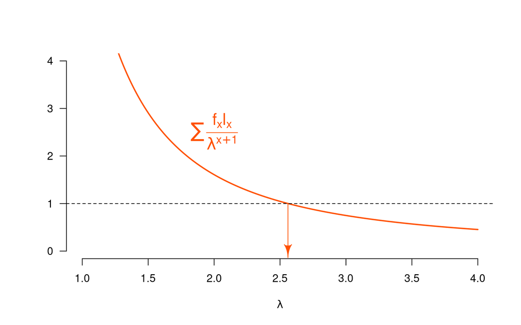

**Solución gráfica de la ecuación de Euler.** Para el ejemplo de los topillos, cuando se representa $\sum f_x l_x \lambda^{-(x+1)}$ en función de los posibles valores de $\lambda$, se alcanza el $1$ cuando $\lambda = 2.55$. Justo el primer valor propio de la matriz de Leslie.

> Una población con clases continuas, sin clases, es decir

La verdad es que Euler, aunque la utilizó implícitamente, no formuló esa relación como la hemos visto. El aspecto moderno de la relación se lo debemos a Alfred Lokta que la dedujo, [en forma continua](https://ia800708.us.archive.org/view_archive.php?archive=/28/items/crossref-pre-1923-scholarly-works/10.1080%252F14786440308635106.zip&file=10.1080%252F14786440408637050.pdf), junto a su profesor Francis Sharpe cuando era, en términos actuales, estudiante de máster en 1909.

En definitiva, la suma de clases discretas que hemos deducido procede de una integral cuando se consideran infinitas clases infinitamente finas:

$$1 = \int_0^\infty \frac{f_x l_x}{\lambda^{x}} dx$$

Aquí, $x$ es la variable edad en forma continua (mira Una de nombres) y, como verdaderamente no hay un límite máximo, la integral se puede definir desde 0 hasta ∞. En este rango, además, se puede sustituir $x+1$ por simplemente $x$, por eso la simplificación del denominador.

# Clases de edad con distinta duración

### La vida de *plankton*

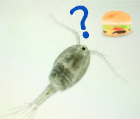

Los copépodos constituyen una fracción muy importante del zooplancton y son un eslabón clave en la transmisión de la producción primaria hacia niveles tróficos superiores. Además, es muy fácil criarlos en acuarios, tal vez por eso se conoce tan bien su biología.

> Etapas en el desarrollo de un copépodo

La vida de estos crustáceos empieza como huevo y después pasa por tres fases: *nauplius* (larva), *copepodito* (juvenil) y *copépodo* (adulto reproductor). La duración media de cada fase depende de la especie y, sobre todo, del entorno. Por ejemplo, cuando *Calanus bonyispon* se cría en un ambiente propicio, la duración media de cada fase es de 2, 6, 10 y 24 días, respectivamente; pero en su vida salvaje pueden permanecer un tiempo indeterminado en cada fase, sobre todo en las primeras, esperando hasta que las condiciones de vida mejoren. En cuanto a la fecundidad, una hembra adulta suele poner 10 huevos por día, cuya mitad son hembras.

Veamos los resultados de un experimento con copépodos criados en cautividad.

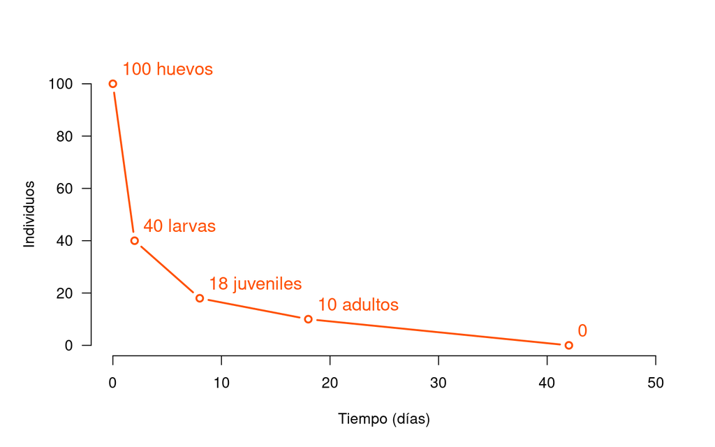

**Seguimiento de una cohorte de huevos de *C. bonyispon*.** De 100 huevos que se incubaron eclosionaron 40 larvas; de estas, 18 llegaron a copepodito y solo 10 hasta copépodo adulto.

> ¿Se puede utilizar una matriz de Leslie?

Las matrices que hemos usado hasta ahora funcionan con clases de la misma duración. En ese intervalo de tiempo solo había dos opciones: sobrevivir hasta la siguiente clase o pasar a mejor vida. Ahora con los copépodos hay un problema: aunque conocemos la supervivencia entre las clases y la cantidad de huevos por hembra… ¿qué representa cada flecha?

[figure not shown]

**Grafo con las clases en la vida del copépodo.** ¿Qué representan las flechas?.

> Tiempo común

Huevo es el estadio más breve. Si suponemos que solo los huevos que han eclosionado en 2 días siguen vivos, podríamos decir que $s_0 = 0.4$ para ese intervalo. Si las demás clases también durasen 2 días, no habría problema, ¿se puede hacer algo?

Si seguimos con la idea de que la edad es la propiedad principal que determina la vida del individuo, una solución consiste en dividir las clases en fracciones de 2 días. Así tendríamos 3 clases de larvas (larvas con 0 o 1 día, con 2 o 3 días y con 4 o 5 días), 5 clases de juveniles y 12 de adultos. Y todas con la misma duración de 2 días.

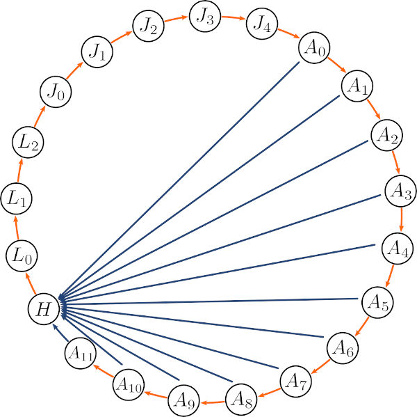

**Grafo con clases de edad de la misma duración.** Las flechas naranjas representan la supervivencia $s_x$ y las azules son la fecundidad $f_x$, ambas definidas sobre un periodo de 2 días.

El cálculo de la supervivencia entre las nuevas subclases es un poco truculento. Por ejemplo, solo 18 de 40 larvas (45 %) llegan a juvenil, pero ahora tienen que atravesar 3 subclases. ¿Cuánto valen las supervivencias parciales?

Se tiene que cumplir que

$$J_{0,t+3} = 0.45 L_{0,t}$$

porque transcurren 3 subclases de edad. Si llamamos $s_i$ a la supervivencia parcial, suponemos que es constante dentro de las larvas y expandimos la clase, tendríamos

$$\begin{align}
L_{1,t+1} &= s_i L_{0,t} \\
L_{2,t+2} &= s_i L_{1,t+1} = s_i^2 L_{0,t} \\
J_{0,t+3} &= s_i L_{2,t+2} = s_i^3 L_{0,t}
\end{align}$$

Así que

$$s_i^3 = 0.45$$

o sea,

$$s_i = \sqrt[3]{0.45} = 0.77$$

De forma análoga se pueden calcular las supervivencias para los juveniles, cuya supervivencia global es del 56 %:

$$s_i = \sqrt[5]{0.56} = 0.89$$

Para los adultos es más chungo, porque la última subclase debe tener supervivencia nula, pero las anteriores no. Podemos asumir que se llega desde 10 a 1 de esta forma geométrica en las primeras once subclases adultas y, después, el último se muere en la última subclase. Es decir,

$$\begin{align}
s_i &= \sqrt[11]{0.1} = 0.81 \\
s_{21} &= 0
\end{align}$$

Las fecundidades parciales, sin embargo, son triviales:

$$f_i = \frac{f_x}{n}$$

que, para el caso, sale $f_i = \frac{5 \times 24}{12} = 10$ huevos hembra por hembra adulta.

Veamos la tabla de vida con todos estos coeficientes:

Tabla de vida para *C. bonyispon* en 21 subclases de 2 días de duración cada una.

| Clase | Edad (días) | $s_i$ | $l_i$ | $f_i$ |
| --- | --- | --- | --- | --- |
| Huevo | 0 - 1 | 0.40 | 1.00 | 0 |
| Larva 0 | 2 - 3 | 0.77 | 0.40 | 0 |
| Larva 1 | 4 - 5 | 0.77 | 0.31 | 0 |
| Larva 2 | 6 - 7 | 0.77 | 0.23 | 0 |
| Juvenil 0 | 8 - 9 | 0.89 | 0.18 | 0 |
| Juvenil 1 | 10 - 11 | 0.89 | 0.16 | 0 |
| Juvenil 2 | 12 - 13 | 0.89 | 0.14 | 0 |
| Juvenil 3 | 14 - 15 | 0.89 | 0.13 | 0 |
| Juvenil 4 | 16 - 17 | 0.89 | 0.11 | 0 |
| Adulto 0 | 18 - 19 | 0.81 | 0.10 | 10 |
| Adulto 1 | 20 - 21 | 0.81 | 0.08 | 10 |
| Adulto 2 | 22 - 23 | 0.81 | 0.07 | 10 |
| Adulto 3 | 24 - 25 | 0.81 | 0.05 | 10 |
| Adulto 4 | 26 - 27 | 0.81 | 0.04 | 10 |
| Adulto 5 | 28 - 29 | 0.81 | 0.04 | 10 |
| Adulto 6 | 30 - 31 | 0.81 | 0.03 | 10 |
| Adulto 7 | 32 - 33 | 0.81 | 0.02 | 10 |
| Adulto 8 | 34 - 35 | 0.81 | 0.02 | 10 |
| Adulto 9 | 36 - 37 | 0.81 | 0.02 | 10 |
| Adulto 10 | 38 - 39 | 0.81 | 0.01 | 10 |
| Adulto 12 | 40 - 41 | 0.00 | 0.01 | 10 |

De la tabla de vida ya se puede calcular $R_0 = 4.9$ definido sobre el periodo de 21 clases (42 días).

Veamos la matriz de Leslie correspondiente, aunque si solo la tabla ya es aparatosa, te puedes imaginar la matriz de 21 × 21. En parte:

$$\mathbf{L} =
\begin{pmatrix}
0 & 0 & \cdots & \cdots & \cdots & \cdots & 10 & 10 \\
0.40 & 0 & \cdots & \cdots & \cdots & \cdots & 0 & 0 \\
0 & 0.77 & \cdots & \cdots & \cdots & \cdots & 0 & 0 \\
0 & 0 & \cdots & \cdots & \cdots & \cdots & 0 & 0 \\
\cdots & \cdots & \cdots & \cdots & \cdots & \cdots & 0 & 0 \\
0 & 0 & \cdots & 0.89 & \cdots & \cdots & 0 & 0 \\
\cdots & \cdots & \cdots & \cdots & \cdots & \cdots & 0 & 0 \\
0 & 0 & \cdots & \cdots & \cdots & 0.81 & 0 & 0 \\
0 & 0 & \cdots & \cdots & \cdots & 0 & 0.81 & 0 \\
\end{pmatrix}$$

Para trabajar con matrices tan grandes es mejor contar con la ayuda de algún programa. Hay mucho *software* libre capaz de hacerlo, como [Octave](https://www.gnu.org/software/octave/index), [Maxima](https://maxima.sourceforge.io/es/) o [R](https://www.r-project.org/)

```r
# Definir el tamaño de la matriz y rellenarla de ceros
L <- matrix(0, nrow = 21, ncol = 21)

# Rellenar la fila de fecundidades
L[1, 10:21] <- 10

# Rellenar la subdiagonal de supervivencias
L[2, 1] <- 40/100
for (i in 2:4) {
    L[i + 1, i] <- (18/40)^(1/3)
}
for (i in 5:9) {
    L[i + 1, i] <- (10/18)^(1/5)
}
for (i in 10:20) {
    L[i + 1, i] <- (1/10)^(1/11)
}

# Pedir a R que calcule los valores y vectores propios
eigen(L)
```

De la matriz $\mathbf{L}$ se obtiene la tasa finita de crecimiento $\lambda = 1.13$, definida sobre un periodo de tiempo de 2 días. Del vector propio asociado se deducen las proporciones de clases en equilibrio:

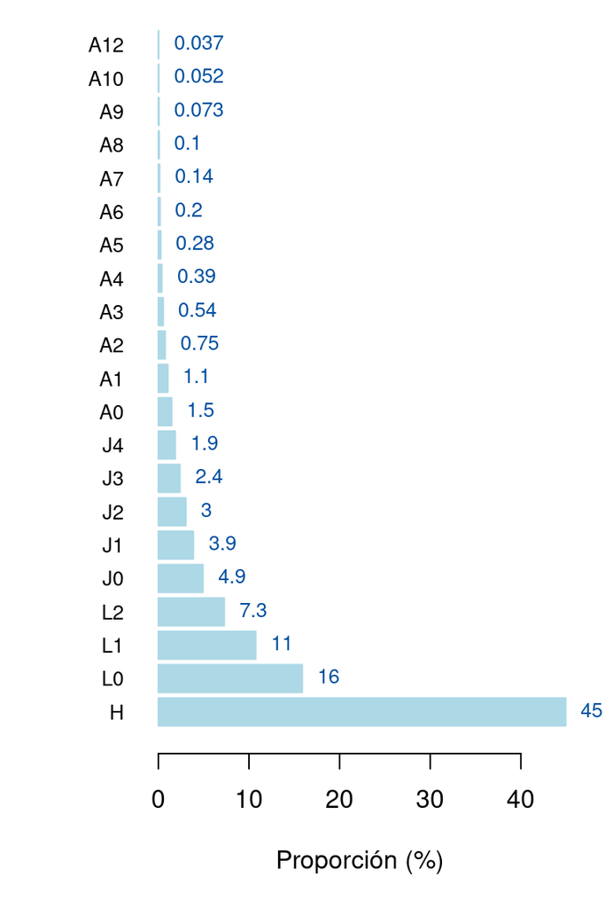

**Distribución estable de clases para *C. bonyispon*.** Obtenida a partir del primer vector propio de $\mathbf{L}$.

Y si unimos las abundancias por clases nominales:

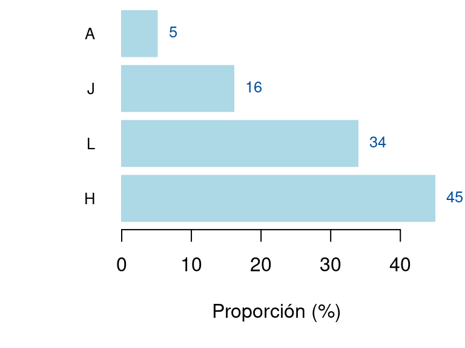

**Distribución estable de clases para *C. bonyispon*.** Sumando las subclases correspondientes.

# Clases con otros criterios

> La fecundidad y supervivencia no siempre están relacionadas estrictamente con la edad, como ocurre en organismos grandes como los mamíferos. La gran mayoría de especies pasan por una serie de fases con características intrínsecas y duración indefinida.

Cuando la edad no es determinante en la transición entre dos fases es muy difícil aplicar una matriz de Leslie del tipo *evolucionas o mueres*. Como los procesos no dependen estrictamente del tiempo, solo se puede establecer la probabilidad de transición.

### *Bonyispon* visita Montecarlo

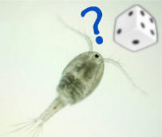

Los copépodos, como muchos artrópodos, pueden ralentizar algunas fases hasta casi detener el metabolismo en *diapausa*, esperando el momento propicio para desarrollarse. Los huevos, larvas y juveniles pueden pasar un tiempo indeterminado en cada fase.

> Probabilidad de transición

Supongamos por ahora que no hay mortalidad, simplemente un reposo en cada clase hasta que se produce el paso a la siguiente. Así, se puede definir una *probabilidad de transición* en función del número de individuos que maduran en cierto periodo de tiempo.

En el caso de los huevos, el 40 % de ellos pasan a larva en un periodo de dos días. Podemos decir, entonces, que la probabilidad de eclosionar es 0.4 y la probabilidad de quedar en diapausa es 0.6 pero, claro, en dos días. ¿Cuál es la probabilidad de eclosionar en 1 día? Si aplicamos el mismo criterio de los visones podríamos decir que 0.2 (la mitad) aunque ya podemos ser más precisos. Si llamamos $p$ a esa probabilidad y $q$ a la complementaria, es decir, quedar en diapausa ¿qué fracción de huevos se quedará sin eclosionar en 2 días? Está claro que $q^2$ (probabilidad de no eclosionar el primer día $\times$ probabilidad de no eclosionar el segundo día), es decir, $(1 - p)^2$. Así que,

$$(1 - p)^2 = 0.6$$
luego,

$$p = 1 - \sqrt{0.6} = 0.23$$

Ya ves, un poco mayor que lo supuesto inicialmente.

Por otro lado, un 45 % de las larvas maduran a juveniles en 6 días. ¿Cuál es la probabilidad de madurar a juvenil en un día? De forma análoga,

$$(1 - p)^6 = 1 - 0.45$$
luego,

$$p = 1 - \sqrt[6]{0.55} = 0.095$$

De 18 juveniles, 10 llegan a adulto en 10 días, lo que da uno por día, pero el cálculo más correcto, siguiendo los pasos anteriores, dice que la probabilidad de madurar en un día es

$$p = 1 - \sqrt[10]{1 - \frac{10}{18}} = 0.078$$

Finalmente, los últimos 10 adultos desaparecen en 24 días. En este caso mueren, no se quedan en diapausa. ¿Cuál es la probabilidad de morir en 1 día? Si te fijas, verás que no se puede aplicar la regla anterior (no se puede dividir por 0), esto significa que, por muy grande que sea la probabilidad de desparecer, siempre queda una fracción viva. Se puede, no obstante, decidir que ya no queda ningún copépodo cuando esta fracción sea menor que 0,5 individuos. En este caso, nos interesa la probabilidad de permanecer vivo:

$$0.5 = 10 q^{24}$$

así que,

$$q = \sqrt[24]{\frac{0.5}{10}} = 0.88$$

Podemos resumir estas probabilidades en el siguiente grafo:

[figure not shown]

**Grafo con probabilidades diarias de transición y persistencia.** Suponiendo que la mortalidad solo se produce en la última clase, ahora existe la posibilidad de cambiar de clase o persistir en la misma. No se representa la fecundidad, por ahora.

Con este planteamiento se mantienen las clases originales, que ahora ya no son de edad. Cmo los individuos pueden permanercer en una clase o pasar a la siguiente durante un periodo indefinido, el concepto de cohorte se diluye conforme pasa el tiempo.

La matriz correspondiente, incluyendo la fecundidad, es

$$\mathbf{L} =
\begin{pmatrix}
0.77 & 0 & 0 & 5 \\
0.23 & 0.905 & 0 & 0 \\
0 & 0.095 & 0.922 & 0 \\
0 & 0 & 0.078 & 0.88 \\
\end{pmatrix}$$

cuyo primer valor propio es $\lambda = 1.18$ definido sobre un periodo de 1 día. Y las proporciones estables de clases son:

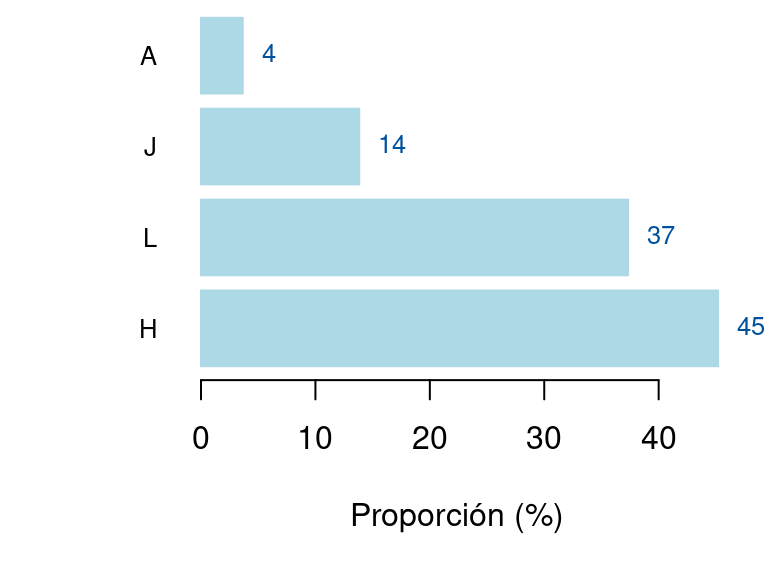

**Distribución estable de clases para *C. bonyispon*.** Obtenida a partir del primer vector propio de la nueva matriz $\mathbf{L}$.

Los resultados se parecen mucho a los del apartado anterior basado en edades aunque, claro, no pueden coincidir. El valor de $\lambda$ equivalente para 2 días es $1.18^2 = 1.39$ que es bastante mayor que el 1.13 obtenido antes, lo que no es raro pues aquí se ha considerado que la mortalidad solo ocurre en los adultos. Si se aplica una tasa de mortalidad extra del 20 % a las demás clases, entonces aparece aproximadamente el mismo valor.

¿Qué planteamiento es mejor? No se puede decir, depende del caso. Cuando la edad es determinante de las propiedades reproductivas y de supervivencia, tal vez el enfoque basado en muchas clases de la misma duración sea más correcto. Por otro lado, cuando las clases representen estadios de duración indefinida, será más cómodo trabajar con la segunda estrategia, considerando las probabilidades de permanecer en un estado o mutar a otro.

# Ejercicios selectos

## 1. Las ardillas de Utah

De un [estudio](https://kuscholarworks.ku.edu/bitstream/handle/1808/18033/Slade_1974.pdf) de una población de ardillas terrestres se dedujo la siguiente tabla de vida para las hembras (simplificada):

Tabla de vida de *Spermophilus armatus*. La clase es la edad en años.

| Clase | $l_x$ | $f_x$ |
| --- | --- | --- |
| 0 | 1.000 | 0.0 |
| 1 | 0.332 | 1.3 |
| 2 | 0.142 | 1.9 |
| 3 | 0.061 | 2.0 |
| 4 | 0.026 | 2.1 |
| 5 | 0.011 | 2.1 |

1. Calcula $R_0$
2. Construye la matriz de Leslie
3. Calcula $\lambda$
4. Representa la estructura estable de edades
5. ¿Qué clase tiene mayor valor reproductivo?

## 2. Los cuervos del Puerto de la Torre

Al norte de Málaga, entre los valles del Guadalmedina y el Guadalhorce se extiende una abrupta zona de lomas y barrancos, parcialmente antropizada con huertos y fincas abandonadas, explotada por ganado caprino/ovino y también por algunos cotos de caza. En este inhóspito sitio prolifera la vida silvestre con comodidad olvidada de los gestores medioambientales. Entre las especies más llamativas que se pueden observar hay un número indeterminado de parejas de cuervos, que parece aumentar a un ritmo del 20 % anual. Estos enormes pájaros ponen una media de 5 huevos por temporada, alcanzan la madurez sexual a los tres años y suelen mantener la pareja durante una larga vida que puede llegar hasta los cuarenta años, incluso más. Cada pareja suele explotar unas 80 hectáreas, que defienden con fiereza. Supongamos que la tasa de mortalidad es independiente de la edad, como suele ocurrir generalmente en los paseriformes que viven en libertad.

1. Construye la matriz de Leslie.
2. Si actualmente se cree que hay unas 15 parejas, ¿en cuánto tiempo ocuparán los 160 km² que aproximadamente tiene ese territorio?

## 3. *Biznaguero’s delight & climate change*

Allí donde empieza la cuesta de la Tana, el Fali cogió unas cuantas sombrillitas de *Visnaga bravida* para que su abuela pudiera ensartar jazmines en pleno solaz veraniego.

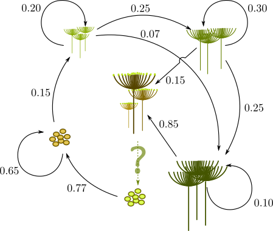

**Grafo vital de *V. bravida*.** Hay plantas pequeñas, medianas y grandes. Solo estas dos últimas suelen echar flores, de las que salen un número indeterminado de semillas antes de marchitarse. Las semillas deben pasar un invierno para activarse y después germinan, si tienen suerte. Las flechas representan la probabilidad de paso entre cada clase.

La ofrenda tuvo tanto éxito que se estableció como rito anual. El Fali llegó a contable de banco y, por deformación profesional, fue anotando las plantas que se iba encontrando cada año. Se dio cuenta de que algunas plantas que no florecían se mantenían vivas hasta el año siguiente creciendo en tamaño, sin duda por culpa del cambio climático. También observó que el número de plantas siempre era el mismo, a pesar de las 16 sombrillitas qe cogía cada año (¡de las grandes, faltaría menos!).

1. ¿Por qué la flecha verde no puede interpretarse como probabilidad?
2. Por cierto, ¿cuántas semillas producía cada planta?
3. Adivina la abundancia de cada tamaño de planta (el número mínimo vale)

## 4. El mixomiceto marciano

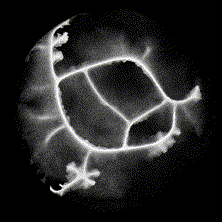

En un experimento dentro de un proyecto encaminado a terraformar Marte, se ha diseñado mediante CRISPR un mixomiceto autótrofo con las siguientes propiedades (referidas al número de núcleos):

$$\begin{align}
l_x &= 0.01 x^2 - 0.2 x + 1 \\
f_x &= 0.1 x^3
\end{align}$$

siendo $x$ la edad del plasmodio en días.

1. ¿Cuál es la máxima longevidad de un núcleo?
2. Calcula $R_0$
3. Calcula $\lambda$
4. ¿Crees que podrá colonizar Marte?